© Bản quyền thuộc về Quantopian Inc.  
© Bản quyền sửa đổi thuộc về AI Cafe¹  
Giấy phép [Creative Commons Attribution 4.0](https://creativecommons.org/licenses/by/4.0/legalcode).  
[Khuyến cáo](https://aicafe.one/khuyen-cao/)

# Mô hình định giá tài sản (CAPM) và lý thuyết chênh lệch giá

by Beha Abasi, Maxwell Margenot, and Delaney Granizo-Mackenzie

Edited by AI Cafe¹

Mô hình Định giá Tài sản Vốn (CAPM) là một thước đo kinh điển về chi phí vốn. Nó thường được sử dụng trong tài chính để đánh giá giá trị của tài sản và để đánh giá tác động của phần bù rủi ro từ thị trường nói chung. Trong bài giảng này, chúng ta sẽ thảo luận về CAPM và Lý thuyết Định giá Dịch chuyển (APT) tổng quát hơn để hình thành cơ sở cho việc đánh giá rủi ro liên quan đến các yếu tố khác nhau.

```python
import numpy as np
import pandas as pd
import statsmodels.api as sm
from statsmodels import regression
import matplotlib.pyplot as plt
```

## Rủi ro Đặc thù và Rủi ro Hệ thống

Nói chung, danh mục đầu tư và tài sản có thể phải đối mặt với hai loại rủi ro: rủi ro đặc thù và rủi ro hệ thống. **Rủi ro đặc thù** đề cập đến những rủi ro cụ thể cho từng công ty và có thể được đa dạng hóa, chẳng hạn như thay đổi trong ban quản lý hoặc sản xuất bị lỗi, trong khi **rủi ro hệ thống** là rủi ro trên toàn thị trường và ảnh hưởng đến tất cả các thành viên trong thị trường. Một ví dụ có thể là sự chậm lại của nền kinh tế hoặc thay đổi trong lãi suất. Vì tất cả các công ty đều chịu ảnh hưởng của rủi ro hệ thống, nên nó không thể được đa dạng hóa.

## Phần thưởng Rủi ro

Khi số lượng tài sản trong một danh mục đầu tư tăng lên, nhiều rủi ro đặc thù sẽ bị loại bỏ và được đa dạng hóa. Đây là lý do chính khiến chúng ta muốn tránh rủi ro tập trung vào một vị thế. Khi danh mục đầu tư của bạn lớn hơn và thực hiện nhiều lần cược độc lập thông qua việc đa dạng hóa, phương sai của danh mục đầu tư sẽ giảm cho đến khi chỉ còn lại rủi ro hệ thống. Vì chúng ta không thể loại bỏ rủi ro hệ thống, các nhà đầu tư phải được nhận một phần thưởng rủi ro cao hơn mức lợi suất không rủi ro để bù đắp cho rủi ro mà họ phải gánh chịu khi đầu tư vào danh mục này. Những rủi ro ở cấp độ công ty riêng lẻ trong danh mục này không có phần thưởng liên quan vì điều này sẽ tạo ra cơ hội chênh lệch giá. Các cổ đông có thể thu thập phần thưởng rủi ro trong khi đa dạng hóa rủi ro liên quan đến họ. Điều này có nghĩa là lợi nhuận bổ sung mà không có thêm mức độ rủi ro nào. Đây là định nghĩa của một cơ hội chênh lệch giá!

Từ lý luận này, chúng ta có thể kết luận rằng mức phần thưởng rủi ro của một tài sản không nên có mối quan hệ với rủi ro đặc thù của nó, mà thay vào đó chỉ nên dựa vào mức độ rủi ro hệ thống mà nó mang lại. Để tính toán chính xác mức phần thưởng rủi ro của một tài sản, và do đó là lợi nhuận kỳ vọng của chúng ta, chúng ta cần tìm một thước đo về rủi ro hệ thống. Nếu chúng ta có điều đó, thì chúng ta có thể định nghĩa lý thuyết lợi nhuận của một tài sản theo cách sau:

$$E[\mbox{Lợi nhuận}] = \mbox{Lợi suất không rủi ro} + \mbox{Phần thưởng rủi ro}$$

Một cách để làm điều này là ước lượng cách mà sự thay đổi trong lợi suất vượt trội của một tài sản liên quan đến sự thay đổi trong lợi suất vượt trội của thị trường. Biểu diễn điều này dưới dạng hồi quy tuyến tính sẽ cho chúng ta mối quan hệ như là sự thay đổi trong lợi nhuận kỳ vọng của một tài sản cho mỗi 1% thay đổi trong lợi suất của danh mục thị trường.

Về lý thuyết, danh mục thị trường này không nên còn rủi ro có thể phân tán và do đó chỉ dao động với các cú sốc hệ thống. Trong thực tế, chúng ta sử dụng một chỉ số thị trường như VNINDEX làm đại diện cho danh mục thị trường. Beta mà chúng ta nhận được từ việc hồi quy lợi suất của một tài sản với lợi suất của thị trường sẽ là thước đo rủi ro hệ thống của chúng ta. Beta này đại diện cho độ nhạy của dòng lợi suất của một tài sản đối với các cú sốc toàn thị trường.

Với beta này, phần thưởng rủi ro của tài sản $i$ được định nghĩa là:

$$\mbox{Phần thưởng rủi ro của Tài sản}_i = \beta (\mbox{Phần thưởng rủi ro thị trường})$$

Chúng ta gọi mô hình đơn giản này là Mô hình Định giá Tài sản Vốn (CAPM).

## Lý thuyết Định giá Tài sản Vốn

Chúng ta có thể diễn đạt CAPM một cách rõ ràng hơn như sau:

$$E[R_i] = R_F + \beta(E[R_M] - R_F)$$

Trong đó $R_i$ là lợi suất của tài sản $i$, $R_F$ là tỷ lệ không rủi ro, và $R_M$ là lợi suất của thị trường. CAPM là một trong những thước đo cơ bản nhất về chi phí vốn. Nó xác định lợi suất tối thiểu cần thiết để thu hút các nhà đầu tư nắm giữ một tài sản nhất định.

Nói một cách khác, CAPM cho rằng lợi suất của một tài sản nên là tỷ lệ không rủi ro, mà đó là điều chúng ta yêu cầu để bù đắp cho lạm phát và giá trị thời gian của tiền, cũng như một khoản bổ sung để bù đắp cho mức độ rủi ro hệ thống mà chúng ta đang phải đối mặt.

```python
# Cài thư viện lấy dữ liệu miễn phí
!curl -fsSLO https://raw.githubusercontent.com/algo-stocks/data/master/data.py
```

OLS Regression Results

| Dep. Variable: | y | R-squared: | 0.349 |
| --- | --- | --- | --- |
| Model: | OLS | Adj. R-squared: | 0.346 |
| Method: | Least Squares | F-statistic: | 131.8 |
| Date: | Thu, 24 Apr 2025 | Prob (F-statistic): | 1.04e-24 |
| Time: | 00:38:42 | Log-Likelihood: | 736.97 |
| No. Observations: | 248 | AIC: | -1470. |
| Df Residuals: | 246 | BIC: | -1463. |
| Df Model: | 1 |  |  |
| Covariance Type: | nonrobust |  |  |

|  | coef | std err | t | P>\|t\| | [0.025 | 0.975] |
| --- | --- | --- | --- | --- | --- | --- |
| const | 0.0019 | 0.001 | 2.388 | 0.018 | 0.000 | 0.003 |
| VNINDEX | 1.0614 | 0.092 | 11.479 | 0.000 | 0.879 | 1.244 |

| Omnibus: | 16.966 | Durbin-Watson: | 1.759 |
| --- | --- | --- | --- |
| Prob(Omnibus): | 0.000 | Jarque-Bera (JB): | 20.274 |
| Skew: | 0.543 | Prob(JB): | 3.96e-05 |
| Kurtosis: | 3.885 | Cond. No. | 117. |

Notes:  
[1] Standard Errors assume that the covariance matrix of the errors is correctly specified.

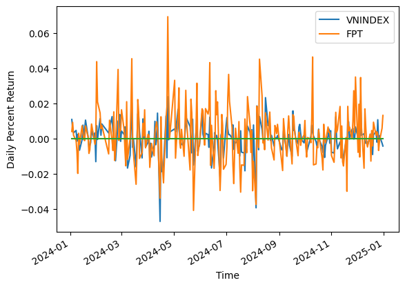

```python
from data import get_prices

start = '2024-01-01'
end = '2025-01-01'

closes = get_prices('FPT', 'VNINDEX', start_date=start, end_date=end).dropna()

# Stock returns
R = closes.FPT.pct_change().dropna()

# Risk free rate 2024
R_F = pd.Series(0.05 / 252, index=R.index)

# find it's beta against market
M = closes.VNINDEX.pct_change().dropna()

FPT_results = regression.linear_model.OLS(R-R_F, sm.add_constant(M)).fit()
FPT_beta = FPT_results.params.iloc[1]

M.plot()
R.plot()
R_F.plot()
plt.xlabel('Time')
plt.ylabel('Daily Percent Return')
plt.legend()

FPT_results.summary()
```

Chúng ta có thể sử dụng mức độ beta mà chúng ta đã tính toán để đưa ra dự đoán về lợi nhuận.

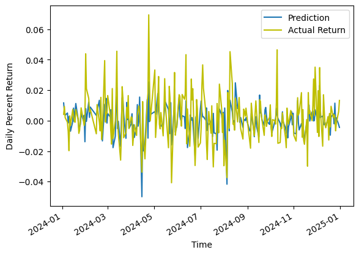

```python
predictions = R_F + FPT_beta*(M - R_F) # CAPM equation

predictions.plot()
R.plot(color='y')
plt.legend(['Prediction', 'Actual Return'])

plt.xlabel('Time')
plt.ylabel('Daily Percent Return');
```

## Giả định CAPM

Trong quá trình suy diễn CAPM, chúng ta đã đưa ra hai giả định chính:

- Chúng ta giả định rằng các nhà đầu tư có khả năng giao dịch mà không bị trì hoãn hay tốn chi phí và rằng mọi người có thể vay hoặc cho vay tiền với lãi suất phi rủi ro.
- Chúng ta giả định rằng tất cả các nhà đầu tư là "những người tối ưu hóa trung bình-phương sai". Điều này có nghĩa là họ chỉ yêu cầu các danh mục đầu tư có lợi suất cao nhất có thể cho một mức độ rủi ro nhất định. Những danh mục này đều nằm dọc theo **đường biên hiệu quả**.

Dưới đây là một suy diễn chương trình về đường biên hiệu quả cho các danh mục đầu tư của bốn tài sản.

```python
from scipy import optimize
import cvxopt as opt
from cvxopt import blas, solvers
```

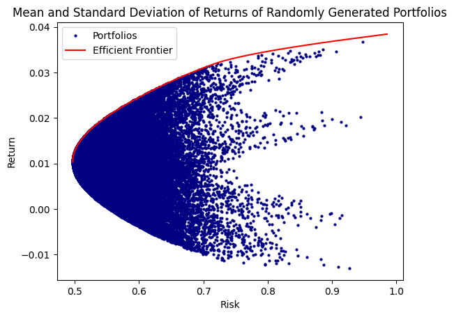

```python
np.random.seed(123)

# Turn off progress printing
solvers.options['show_progress'] = False

# Number of assets
n_assets = 4

# Number of observations
n_obs = 2000

## Generating random returns for our 4 securities
return_vec = np.random.randn(n_assets, n_obs)

def rand_weights(n):
    '''
    Produces n random weights that sum to 1
    '''
    k = np.random.rand(n)
    return k / sum(k)

def random_portfolio(returns):
    '''
    Returns the mean and standard deviation of returns for a random portfolio
    '''

    p = np.asmatrix(np.mean(returns, axis=1))
    w = np.asmatrix(rand_weights(returns.shape[0]))
    C = np.asmatrix(np.cov(returns))

    mu = w * p.T
    sigma = np.sqrt(w * C * w.T)

    # This recursion reduces outliers to keep plots pretty
    if sigma > 2:
        return random_portfolio(returns)
    return mu, sigma

def optimal_portfolios(returns):
    n = len(returns)
    returns = np.asmatrix(returns)

    N = 100000

    # Creating a list of returns to optimize the risk for
    mus = [100**(5.0 * t/N - 1.0) for t in range(N)]

    # Convert to cvxopt matrices
    S = opt.matrix(np.cov(returns))
    pbar = opt.matrix(np.mean(returns, axis=1))

    # Create constraint matrices
    G = -opt.matrix(np.eye(n))   # negative n x n identity matrix
    h = opt.matrix(0.0, (n ,1))
    A = opt.matrix(1.0, (1, n))
    b = opt.matrix(1.0)

    # Calculate efficient frontier weights using quadratic programming
    portfolios = [solvers.qp(mu*S, -pbar, G, h, A, b)['x']
                  for mu in mus]

    ## Calculate the risk and returns of the frontier
    returns = [blas.dot(pbar, x) for x in portfolios]
    risks = [np.sqrt(blas.dot(x, S*x)) for x in portfolios]

    return returns, risks

n_portfolios = 50000

from IPython.display import clear_output

all_portfolios = []
for x in range(n_portfolios):
    clear_output(wait=True)
    if (x+1) % 10 == 0:
        print(f'creating random portfolio {x+1} of {n_portfolios}')
    all_portfolios.append(random_portfolio(return_vec))

clear_output()
means, stds = np.column_stack(all_portfolios)

returns, risks = optimal_portfolios(return_vec)

plt.plot(stds, means, 'o', markersize=2, color='navy')
plt.xlabel('Risk')
plt.ylabel('Return')
plt.title('Mean and Standard Deviation of Returns of Randomly Generated Portfolios');

plt.plot(risks, returns, '-', markersize=3, color='red');
plt.legend(['Portfolios', 'Efficient Frontier']);
```

Mỗi chấm xanh đại diện cho một danh mục đầu tư khác nhau, trong khi đường đỏ chạy bên ngoài đám mây là đường biên giới hiệu quả. Đường biên giới hiệu quả chứa tất cả các danh mục đầu tư tốt nhất cho một mức độ rủi ro nhất định.

Danh mục đầu tư tối ưu, hay hiệu quả nhất, trên đường này được xác định bằng cách tối đa hóa tỷ lệ Sharpe, tỷ lệ giữa lợi nhuận vượt mức và độ biến động. Chúng tôi sử dụng điều này để xác định danh mục đầu tư có sự trao đổi giữa rủi ro và phần thưởng tốt nhất.

Đường biểu thị các kết hợp khác nhau của một tài sản không có rủi ro với một danh mục đầu tư của các tài sản rủi ro được gọi là Đường Phân bổ Vốn (CAL). Độ dốc của CAL là tỷ lệ Sharpe. Để tối đa hóa tỷ lệ Sharpe, chúng ta cần tìm CAL dốc nhất, trùng với CAL tiếp xúc với đường biên giới hiệu quả. Đó là lý do tại sao danh mục đầu tư hiệu quả đôi khi được gọi là danh mục đầu tư tiếp xúc.

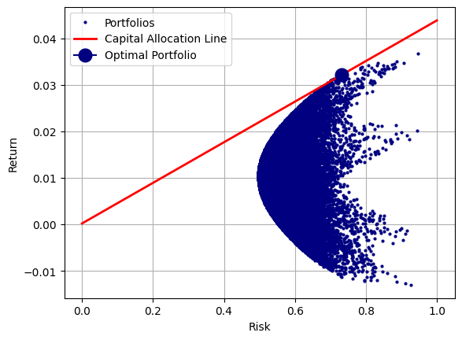

```python
def maximize_sharpe_ratio(return_vec, risk_free_rate):
    """
    Finds the CAPM optimal portfolio from the efficient frontier
    by optimizing the Sharpe ratio.
    """

    def find_sharpe(weights):

        means = [np.mean(asset) for asset in return_vec]

        numerator = sum(weights[m]*means[m] for m in range(len(means))) - risk_free_rate

        denominator = np.sqrt(weights.T.dot(np.corrcoef(return_vec).dot(weights)))

        return numerator/denominator

    guess = np.ones(len(return_vec)) / len(return_vec)

    def objective(weights):
        return -find_sharpe(weights)

    # Set up equality constrained
    cons = {'type':'eq', 'fun': lambda x: np.sum(np.abs(x)) - 1}

    # Set up bounds for individual weights
    bnds = [(0, 1)] * len(return_vec)

    results = optimize.minimize(objective, guess,
                            constraints=cons, bounds=bnds,
                            method='SLSQP', options={'disp': False})

    return results

risk_free_rate = np.mean(R_F)

results = maximize_sharpe_ratio(return_vec, risk_free_rate)

# Applying the optimal weights to each assset to get build portfolio
optimal_mean = sum(results.x[i]*np.mean(return_vec[i]) for i in range(len(results.x)))

optimal_std = np.sqrt(results.x.T.dot(np.corrcoef(return_vec).dot(results.x)))

# Plot of all possible portfolios
plt.plot(stds, means, 'o', markersize=2, color='navy')
plt.ylabel('Return')
plt.xlabel('Risk')

# Line from the risk-free rate to the optimal portfolio
eqn_of_the_line = lambda x : ( (optimal_mean-risk_free_rate) / optimal_std ) * x + risk_free_rate

xrange = np.linspace(0., 1., num=11)

plt.plot(xrange, [eqn_of_the_line(x) for x in xrange], color='red', linestyle='-', linewidth=2)

# Our optimal portfolio
plt.plot([optimal_std], [optimal_mean], marker='o', markersize=12, color="navy")

plt.legend(['Portfolios', 'Capital Allocation Line', 'Optimal Portfolio'])
plt.grid(True)
```

Chúng ta có thể xem xét lợi nhuận và rủi ro của các tài sản riêng lẻ so với danh mục đầu tư tối ưu mà chúng ta đã tìm ra để dễ dàng minh họa sức mạnh của sự đa dạng hóa.

```python
for a in range(len(return_vec)):
    print("Return and Risk of Asset", a, ":", np.mean(return_vec[a]), ",",np.std(return_vec[a]))

print("Return and Risk of Optimal Portfolio", optimal_mean, optimal_std)
```

```
Return and Risk of Asset 0 : -0.015587484342459114 , 0.9799254468194947
Return and Risk of Asset 1 : 0.03841588871479547 , 0.9856584032986271
Return and Risk of Asset 2 : 0.02064673779922475 , 0.9919497385814913
Return and Risk of Asset 3 : -0.0044368654765103805 , 1.003119682183738
Return and Risk of Optimal Portfolio 0.03213007237083454 0.7315250479076123
```

## Đường Thị Trường Vốn là CAL thông qua danh mục thị trường

Danh mục tối ưu của chúng ta có mức lợi nhuận khá cao cũng như rủi ro thấp hơn bất kỳ tài sản cá nhân nào. Về lý thuyết, tất cả các nhà đầu tư đều nên yêu cầu danh mục tối ưu, danh mục tiếp xúc này. Nếu chúng ta tích lũy các danh mục của tất cả các nhà đầu tư, chúng ta sẽ có được danh mục thị trường, vì tất cả các cổ phiếu phải được nắm giữ bởi ai đó. Điều này có nghĩa là danh mục tiếp xúc là danh mục thị trường, về cơ bản nói rằng cầu phải bằng cung.

Khi một tài sản không rủi ro được thêm vào danh mục, Đường Tài sản Vốn trở thành Đường Thị Trường Vốn (CML). Theo CAPM, bất kỳ cổ phiếu hoặc danh mục nào nằm bên phải CML sẽ chứa rủi ro có thể phân tán và do đó không hiệu quả.

Việc ánh xạ beta của từng chứng khoán với lợi nhuận dự kiến của nó dẫn đến Đường Thị Trường Chứng Khoán. Sự khác biệt giữa lợi nhuận của một chứng khoán và lợi nhuận dự kiến như được dự đoán bởi CAPM được gọi là alpha.

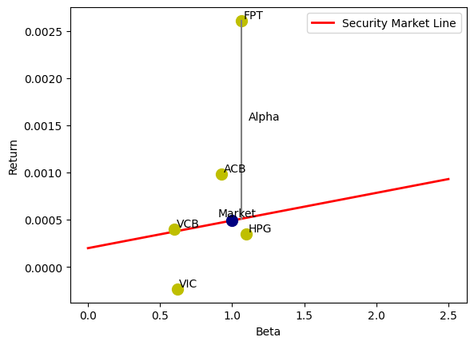

```python
risk_free_rate = np.mean(R_F)

# We have two coordinates that we use to map the SML: (0, risk-free rate) and (1, market return)

eqn_of_the_line = lambda x : ( (np.mean(M)-risk_free_rate) / 1.0) * x + risk_free_rate
xrange = np.linspace(0., 2.5, num=2)
plt.plot(xrange, [eqn_of_the_line(x) for x in xrange], color='red', linestyle='-', linewidth=2)

plt.plot([1], [np.mean(M)], marker='o', color='navy', markersize=10)
plt.annotate('Market', xy=(1, np.mean(M)), xytext=(0.9, np.mean(M)+0.00004))

returns = get_prices('VCB', 'ACB', 'FPT', 'HPG', 'VIC', 'VNINDEX', start_date=start, end_date=end).dropna().pct_change().dropna()
M = returns.VNINDEX
returns = returns.drop(columns=['VNINDEX'])

betas = [
    regression.linear_model.OLS(
        returns[asset],
        sm.add_constant(M)
    ).fit().params.iloc[1]
     for asset in returns.columns
]

for asset, beta in zip(returns.columns, betas):
    plt.plot([beta], [np.mean(returns[asset])], marker='o', color='y', markersize=10)
    plt.annotate(
        asset,
        xy=(beta, np.mean(returns[asset])),
        xytext=(beta + 0.015, np.mean(returns[asset]) + 0.000025)
    )

# drawing the alpha, which is the difference between expected return and the actual return
plt.plot(
    [betas[2], betas[2]],
    [np.mean(returns.iloc[:, 2]), eqn_of_the_line(betas[2])],
    color='grey'
)
plt.annotate(
    'Alpha',
    xy=(
        betas[2] + 0.05,
        (eqn_of_the_line(betas[2])-np.mean(returns.iloc[:,2]))/2+np.mean(returns.iloc[:,2])
    ),
    xytext=(
        betas[2] + 0.05,
        (eqn_of_the_line(betas[2])-np.mean(returns.iloc[:,2]))/2+np.mean(returns.iloc[:,2])
    )
)

plt.xlabel("Beta")
plt.ylabel("Return")

plt.legend(['Security Market Line']);
```

## Lý thuyết định giá chênh lệch

Mô hình CAPM, mặc dù được sử dụng và nghiên cứu rộng rãi, có nhiều nhược điểm. Với những giả định nghiêm ngặt và hạn chế, nó không hoạt động tốt trong các thử nghiệm thực nghiệm. Lý thuyết định giá chênh lệch (APT) nhằm mục đích tổng quát hóa mô hình CAPM, vì các tài sản có thể bị ảnh hưởng bởi các loại rủi ro khác ngoài rủi ro thị trường và các nhà đầu tư có thể quan tâm đến những yếu tố khác ngoài trung bình và phương sai.

APT là một lý thuyết định giá tài sản dựa vào việc diễn đạt lợi nhuận bằng một mô hình yếu tố tuyến tính:

$$R_i = a_i + b_{i1} F_1 + b_{i2} F_2 + \ldots + b_{iK} F_K + \epsilon_i$$

Một yếu tố là một chuỗi lợi nhuận được xác định hoàn toàn bởi một số đặc điểm nào đó. Ví dụ, CAPM chỉ có một yếu tố, đó là lợi nhuận thị trường. Nếu chúng ta đã mô hình hóa tỷ lệ lợi nhuận của mình như trên, thì lợi nhuận kỳ vọng sẽ có dạng:

$$ E(R_i) = R_F + b_{i1} \lambda_1 + b_{i2} \lambda_2 + \ldots + b_{iK} \lambda_K $$

trong đó $R_F$ là lợi suất phi rủi ro, và $\lambda_j$ là phần thưởng rủi ro - lợi nhuận vượt quá lợi suất phi rủi ro - cho yếu tố $j$. Phần thưởng này phát sinh vì các nhà đầu tư yêu cầu lợi nhuận cao hơn để bù đắp cho việc chịu rủi ro cao hơn.

Chúng ta sẽ tính toán phần thưởng rủi ro cho các yếu tố của mình bằng hồi quy Fama-Macbeth. Tuy nhiên, có nhiều cách khác nhau để tính toán mỗi $\lambda_j$!

## Kinh doanh chênh lệch giá

Bây giờ chúng ta đã có một phương pháp khá tổng quát để tính toán lợi nhuận kỳ vọng, chúng ta có thể thảo luận về kinh doanh chênh lệch giá một cách kỹ thuật hơn. Thông thường có rất nhiều chứng khoán trong tập vũ trụ của chúng ta. Nếu chúng ta sử dụng các chứng khoán khác nhau để tính toán $\{\lambda_i\}$, liệu kết quả của chúng ta có nhất quán không? Nếu kết quả của chúng ta không nhất quán, sẽ có một *cơ hội kinh doanh chênh lệch giá* (theo kỳ vọng), một hoạt động tạo ra lợi nhuận mà không phải chịu rủi ro và không cần đầu tư tiền net. Trong trường hợp này, chúng ta có ý nghĩa rằng có một hoạt động không rủi ro với lợi nhuận *kỳ vọng* dương mà không yêu cầu đầu tư net. Điều này xảy ra khi các kỳ vọng về lợi nhuận không nhất quán, tức là rủi ro không được định giá một cách nhất quán giữa các chứng khoán.

Giả sử rằng có một tài sản với tỷ lệ lợi nhuận kỳ vọng là 0.2 cho năm tới và một $\beta$ là 1.2 so với thị trường, trong khi thị trường kỳ vọng có tỷ lệ lợi nhuận là 0.1, và tỷ lệ không rủi ro trên trái phiếu 1 năm là 0.05. Khi đó, mô hình APT cho chúng ta biết rằng tỷ lệ lợi nhuận kỳ vọng trên tài sản nên là

$$ R_F + \beta \lambda = 0.05 + 1.2 (0.1 - 0.05) = 0.11$$

Điều này không đồng nghĩa với dự đoán rằng tài sản sẽ có tỷ lệ lợi nhuận là 0.2. Vậy, nếu chúng ta mua 100 đồng của tài sản của mình, bán khống 120 đồng của thị trường, và mua 20 đồng trái phiếu, chúng ta sẽ không đầu tư tiền net và không phải chịu bất kỳ rủi ro hệ thống nào (chúng ta trung lập với thị trường), nhưng chúng ta kỳ vọng sẽ kiếm được $0.2(100) - 0.1(120) + 0.05(20) = 9$ đồng vào cuối năm.

Mô hình APT giả định rằng những cơ hội này sẽ được tận dụng cho đến khi giá cả thay đổi và các cơ hội kinh doanh chênh lệch giá biến mất. Nghĩa là, nó giả định rằng có những nhà kinh doanh chênh lệch giá có đủ kiên nhẫn và vốn. Điều này cung cấp một lý do cho việc sử dụng các mô hình yếu tố thực nghiệm trong định giá chứng khoán: nếu mô hình không nhất quán, sẽ có một cơ hội kinh doanh chênh lệch giá, và do đó các giá cả sẽ điều chỉnh.

## Đặt cược Cả Hai Chiều

Việc biết chính xác $E(R_i)$ là rất khó khăn, nhưng mô hình này cho chúng ta biết lợi suất kỳ vọng nên là gì nếu thị trường không có cơ hội chênh lệch giá. Điều này tạo nền tảng cho các chiến lược dựa trên hệ thống xếp hạng mô hình yếu tố. Nếu bạn có một mô hình cho lợi suất kỳ vọng của một tài sản, thì bạn có thể xếp hạng các tài sản đó dựa trên hiệu suất kỳ vọng của chúng và sử dụng thông tin này để thực hiện giao dịch. Việc tạo ra một hệ thống xếp hạng là dấu ấn của một chiến lược cổ phiếu Long-Short.

*Lưu ý: Tài liệu này mang tính chất chia sẻ kiến thức khoa học dữ liệu. Các mã chứng khoán xuất hiện trong tài liệu chỉ mang tính chất minh hoạ, không khuyến nghị đầu tư. Chúng tôi không chịu trách nhiệm trước mọi rủi ro nào do sử dụng tài liệu này.*